# Quatro pacotes em R para realizar AED automatizada.

Ferramentas úteis para a análise exploratória de dados por meio de exemplos práticos em R.

Nicolo Cosimo Albanese

Tradução - João Pedro Albino

17/01/2023

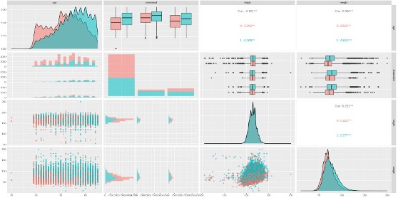

Imagem do autor.

## Índice

1. Introdução
2. Pacotes de Análise de Dados Exploratórios Automatizados  
   2.1 Data Explorer  
   2.2 GGally  
   2.3 SmartEDA  
   2.4 tableone
3. Conclusões
4. Referências

## 1. Introdução

A **Análise Exploratória de Dados** (EDA - *Exploratory Data Analysis*) visa realizar uma investigação inicial sobre os dados, resumindo suas características por meio de técnicas estatísticas e de visualização. É uma etapa inicial crítica em qualquer fluxo de trabalho de Ciência de Dados.  
Neste artigo, serão mostrados quatro pacotes em R que facilitam essa tarefa inicial e fornecem uma ajuda importante no manuseio, visualização e geração de relatórios de dados.  
Como exemplo, será utilizado o Conjunto de Dados de Doenças Cardiovasculares[^1], composto pelos seguintes recursos (dicionário de ddos):

1. id: identificador único do paciente (int)
2. sex : sexo do paciente (1: feminino, 2: masculino)
3. age: idade em dias (int)
4. height: altura em cm (int)
5. weight: peso em kg (float)
6. ap_hi: pressão arterial sistólica (int)
7. ap_lo: pressão arterial diastólica (int)
8. cholesterol: colesterol (1: normal, 2: acima do normal, 3: bem acima do normal)
9. gluc: glicose (1: normal, 2: acima do normal, 3: bem acima do normal)
10. smoke: se o paciente fuma ou não (binário)
11. alco: consumo de álcool (binário)
12. active: atividade física (binário)
13. cardio: presença ou ausência de doença cardiovascular (binário)

Antes de importar o conjunto de dados para a linguagem R, será necessário carregar as bibliotecas que serão utilizadas neste exemplo:

```r
# --- Carregando as bibliotecas
if (!("tidyverse") %in% installed.packages()) install.packages("tidyverse")
if (!("dplyr") %in% installed.packages()) install.packages("dplyr")
if (!("readr") %in% installed.packages()) install.packages("readr")

library(dplyr)
library(readr)
```

O próximo passo é importar o dataset para o R e observar suas primeiras linhas:

```r
# lendo o arquivo em csv
df <-
  read_delim(
    file = "./dados/cardio_train.csv",
    col_types = "iifidiiffffff",
    delim=";")


# pre-processando (preparando os dados)
df <-
  # remover a variável id
  select(df, -id) %>%
  # variável age: transformando dias -> anos
  mutate(age = round(age / 365))

# mostrando as primeiras linhas
head(df)
```

```
## # A tibble: 6 × 12
##     age gender height weight ap_hi ap_lo chole…¹ gluc  smoke alco  active cardio
##   <dbl> <fct>   <int>  <dbl> <int> <int> <fct>   <fct> <fct> <fct> <fct>  <fct>
## 1    50 2         168     62   110    80 1       1     0     0     1      0
## 2    55 1         156     85   140    90 3       1     0     0     1      1
## 3    52 1         165     64   130    70 3       1     0     0     0      1
## 4    48 2         169     82   150   100 1       1     0     0     1      1
## 5    48 1         156     56   100    60 1       1     0     0     0      0
## 6    60 1         151     67   120    80 2       2     0     0     0      0
## # … with abbreviated variable name ¹cholesterol
```

Figura 1. Observação das primeiras colunas.

A *biblioteca Base* do R oferece a função (comando) summary [^2], uma função genérica utilizada para produzir visões gerais de diferentes objetos, tais como de um conjuntos de dados.  
Em particular, quando um conjunto de dados é fornecido como entrada (por exemplo, *summary(df)*), a funçãao retorna diferentes métricas (tais como: média; mediana; min; max; …) para colunas (variáveis) numéricas e a distribuição (contagens) para colunas categóricas.  
A função também retorna informações sobre *dados ausentes* (missing data), se existirem:

```r
summary(df)
```

```
##       age        gender        height          weight           ap_hi
##  Min.   :30.00   2:24470   Min.   : 55.0   Min.   : 10.00   Min.   : -150.0
##  1st Qu.:48.00   1:45530   1st Qu.:159.0   1st Qu.: 65.00   1st Qu.:  120.0
##  Median :54.00             Median :165.0   Median : 72.00   Median :  120.0
##  Mean   :53.34             Mean   :164.4   Mean   : 74.21   Mean   :  128.8
##  3rd Qu.:58.00             3rd Qu.:170.0   3rd Qu.: 82.00   3rd Qu.:  140.0
##  Max.   :65.00             Max.   :250.0   Max.   :200.00   Max.   :16020.0
##      ap_lo          cholesterol gluc      smoke     alco      active
##  Min.   :  -70.00   1:52385     1:59479   0:63831   0:66236   1:56261
##  1st Qu.:   80.00   3: 8066     2: 5190   1: 6169   1: 3764   0:13739
##  Median :   80.00   2: 9549     3: 5331
##  Mean   :   96.63
##  3rd Qu.:   90.00
##  Max.   :11000.00
##  cardio
##  0:35021
##  1:34979
##
##
##
##
```

Figura 2. Saída da função *summary(df)*.

Com as características do conteúdo do dataframe **df** visualizados e compreendidos, mostraremos os quatro pacotes aqui selecionados que fornecem recursos adicionais para a exploração dos dados.

## 2. Pacotes de Análise de Dados Exploratórios Automatizados

### 2.1. DataExplores (Explorador de dados)

O DataExplorer[^3] simplifica e automatiza o processo de AED e a geração de relatórios.  
O pacote verifica automaticamente cada variável e estabelecendo o perfil dos dados (data profilling[^4]) e oferece várias funções úteis para gerar gráficos diferentes em recursos discretos e contínuos. É importante ressaltar que o pacote permite gerar um relatório HTML completo sem esforço invocando a útil função create_report em um conjunto de dados (por exemplo, create_report(df)). É possível passar argumentos adicionais, tal como uma *variável de resposta y*, para adicionar diferentes análises bivariadas ao relatório. O trecho de codigo a seguir produz um arquivo do tipo HTML[^5] no diretório de trabalho.

```r
# Carregando a biblioteca DataExplorer
if (!("DataExplorer") %in% installed.packages()) install.packages("DataExplorer")
library(DataExplorer)

# Criando o relatório em formato HTML
df %>%
  create_report(
    output_file = paste("Report", format(Sys.time(), "%Y-%m-%d %H:%M:%S %Z"), sep=" - "),
    report_title = "Relatório AED - Conjunto de dados sobre doenças cardiovasculares",
    y = "cardio"
  )
```

```
##
##
## processing file: report.rmd
```

[output not shown]

[output not shown]

[output not shown]

[output not shown]

[output not shown]

[output not shown]

[output not shown]

[output not shown]

[output not shown]

[output not shown]

[output not shown]

[output not shown]

```
## output file: /Users/jpalbino/Library/Mobile Documents/com~apple~CloudDocs/GitHub/with-a-little-help-from-my-friends/report.knit.md
```

[output not shown]

```
##
## Output created: Report - 2023-01-17 17:17:11 -03.html
```

Quando aberto em um navegador, o relatório é mostrado da seguinte forma:

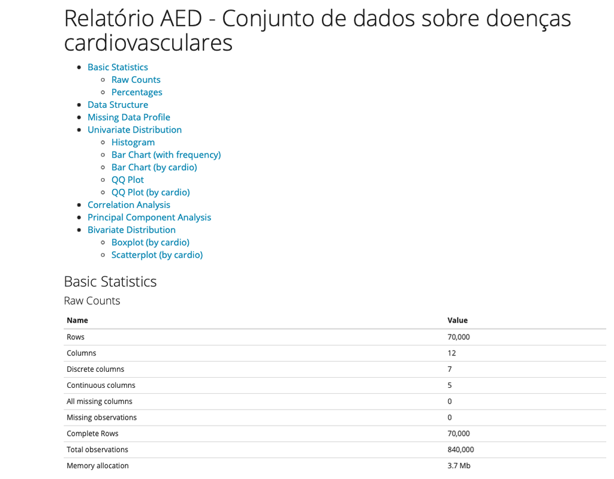

Figura 3. Parte inicial do relatório em HTML.

A parte inicial do relatório em HTML apresenta um sumário detalhado da análise exploratória realizada.  
Como pode ser visto no índice, o relatório compreende a maioria das tarefas realizadas durante o AED e pode ser gerado por uma única linha de código.  
Outras funções adicionais do pacote para tarefas específicas são relatadas individualmente, como por exemplo:

#### 2.1.1 *plot_str(df)*: Plotagem da estrutura do conjunto de dados

```r
plot_str(df)
```

[output not shown]

#### 2.1.2 *plot_bar(df)*: Gráfico de barras para cada variável discreta

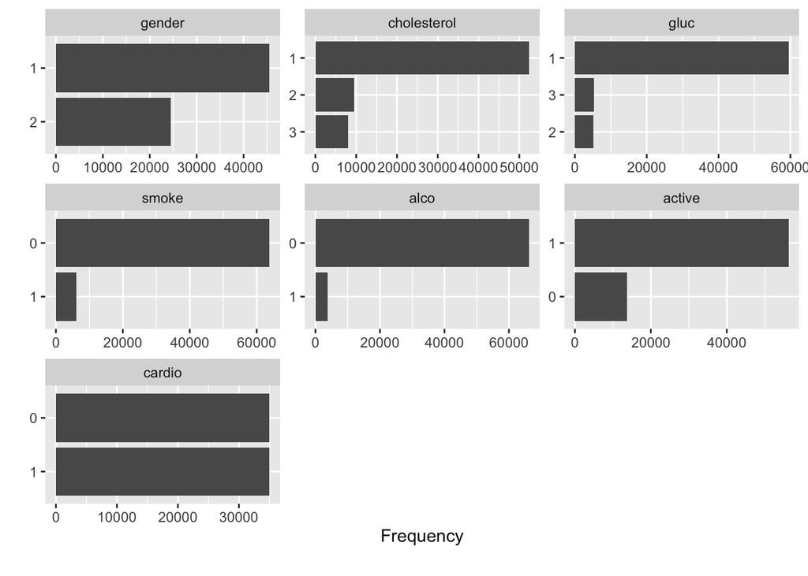

```r
plot_bar(df)
```

Figura 5. Saída do comando plot_bar(df).

#### 2.1.3 *plot_bar(df)*: Gráfico de barras agrupado por uma variável discreta

A apresentação dos gráficos também podem ser agrupados por uma variável discreta, por exemplo, a presença de uma doença cardiovascular, utilizando o comando:

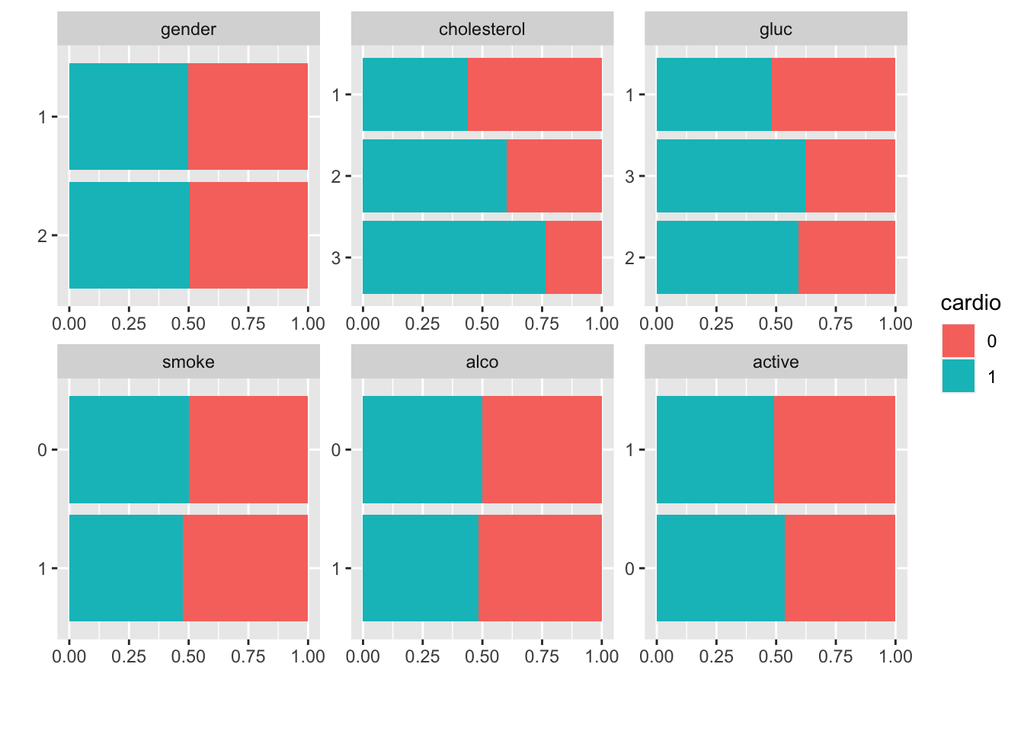

```r
plot_bar(df, by="cardio")
```

Figura 6. Saída do comando plot_bar(df, by=“cardio”), agrupado por uma variável discreta (cardio).

#### 2.1.4 *plot_qq(df)*: Gráfico quantil-quantil para cada variável contínua

Ao observar os gráficos, pode-se observar prontamente que os pacientes com doença cardiovascular apresentam maiores valores de colesterol e podem induzir a melhor investigação do risco de doença cardiovascular representado pelo colesterol mais elevado por meio de testes estatísticos.

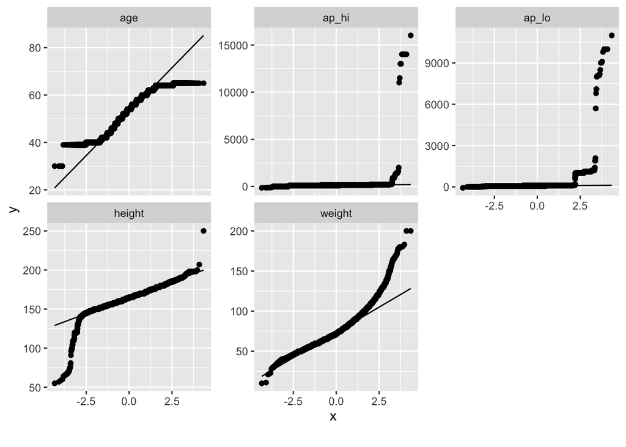

```r
plot_qq(df)
```

Figura 7. Saída do comando plot_qq(df).

#### 2.1.5 *plot_density(df)*: Gráfico de estimativas de densidade para cada característica contínua

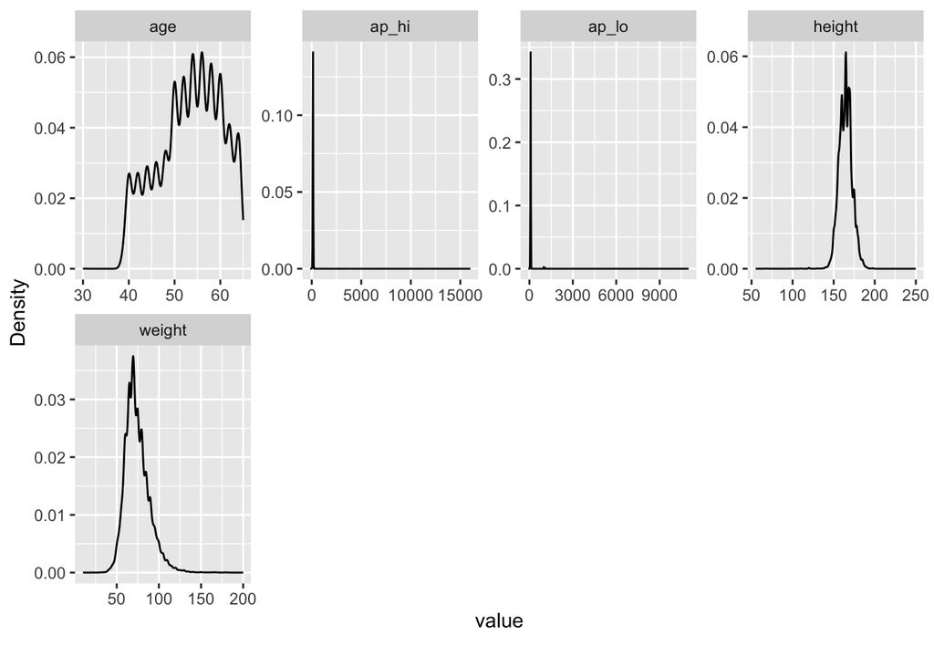

```r
plot_density(df)
```

Figura 8. Saída do comando plot_density(df).

#### 2.1.6 *plot_correlation(df)*: Gráfico de mapa de calor de correlação (heatmap)

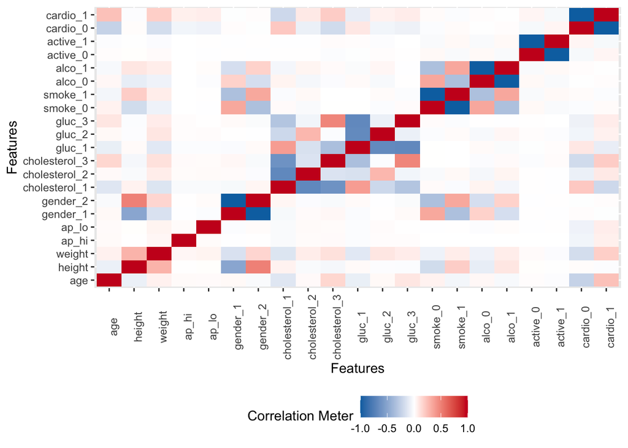

```r
plot_correlation(df)
```

Figura 9. Saída do comando plot_correlation(df).

#### 2.1.7 *plot_prcomp(df)*: Gráfico da Análise de Componentes Principais (PCA)

Este comando realiza a Análise de Componentes Principais (PCA - Principal Component Analysis) e plota a porcentagem de variância explicada por cada componente principal.

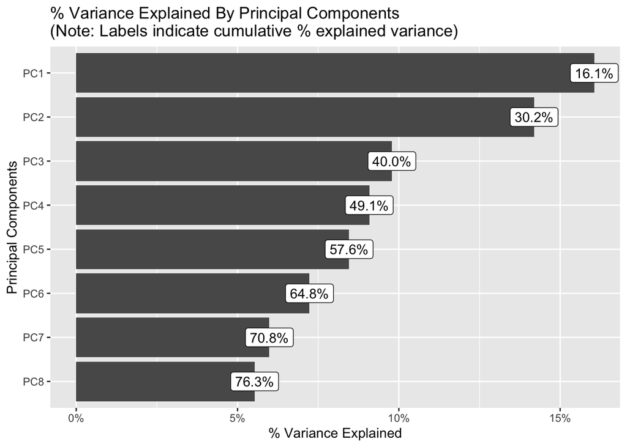

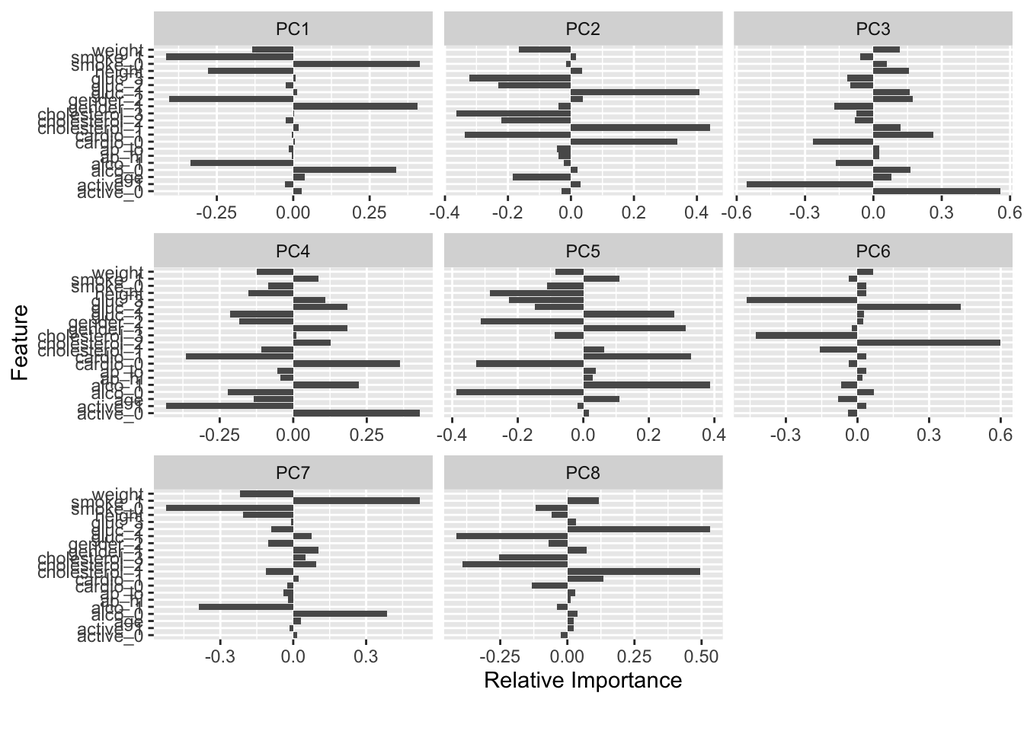

```r
plot_prcomp(df)
```

Figura 9. Saída do comando plot_prcomp(df).

Muitos outros recursos estão disponíveis na documentação do pacote DataExplorer[^6] contém a lista completa das funções disponíveis.

[^1]: Cardiovascular Disease dataset. Disponível em: https://www.kaggle.com/datasets/sulianova/cardiovascular-disease-dataset. Acessado em: 13 jan. 2023.
[^2]: summary: Object Summaries. Disponível em: <rdocumentation.org/packages/base/versions/3.6.2/topics/summary>. Acessado em: 13 jan. 2023.
[^3]: DataExplorer: Automate Data Exploration and Treatment. Disponível em: <cran.r-project.org/package=DataExplorer>. Acessado em: 13 jan. 2023.
[^4]: Perfil de dados (data profilling): Criação de perfil de dados é o processo de revisar a origem dos dados, entender sua estrutura, seu conteúdo e suas inter-relações, além de identificar o potencial desses dados para o projeto.
[^5]: HTML (abreviação para a expressão inglesa HyperText Markup Language, que significa: “Linguagem de Marcação de Hipertexto”) é uma linguagem de marcação utilizada na construção de páginas na Web. Documentos HTML podem ser interpretados por navegadores.
[^6]: <cran.r-project.org/package=DataExplorer>